# Business Statistics End of Term Assessment IB94X0 2024-2025 #1

5613045

I declare that the submitted work is my own and that those external sources have been identified and cited according to the university’s plagiarism regulations. AI tools were utilized for code enhancement and as well as assistance, all analysis, interpretation and conclusions were drawn solely by me. This assignment was completed without breaking any rules or policies of the university.

# Question 1

## Introduction

In England, Cardiovascular Disease (CVD) is a major public health problem that accounts for a significant burden of morbidity and mortality. CVD prevalence is not distributed evenly across individuals, regions, or nations; this paper addresses factors which may help explain the degree of variation in CVD prevalence between local authorities, with implications for both preventative efforts and health policy decision making. This analysis explores the association between CVD prevalence and numerous social and lifestyle factors, including the percentage of the population who are overweight, percentage living in poverty, percentage who smoke, and mean well-being score per region. Using data from the UK Office of National Statistics, advanced statistical approaches will be applied to these variables to determine which ones are most important to the prevalence of CVD. A further detailed visualization will also be made demonstrating how poverty affects CVD rates. Results will be summarized using Office for National Statistics (ONS) data tabling and re-population conventions in order to strengthen the transparency and accessibility of the findings.

## Data Dictionary

[output not shown]

## Explorartory Analysis

```r
# Data Import : we imported the dataset in R Studio through the use of the read_csv function from the read r package. This enables CSV files to seamlessly load into R for further exploration. Summary Statistics Once the data is imported, summary statistics were created to get a feel for the data. Using this step gave an idea of means, medians, ranges, counts, etc., all of which are good indicators of the distribution and variability in the data.

cvd_data <- read_csv("Cardio_Vascular_Disease.csv")
# Summary statistics
summary(cvd_data)
```

```
##   area_name          area_code           Population         Poverty
##  Length:385         Length:385         Min.   :   1960   Min.   :12.90
##  Class :character   Class :character   1st Qu.: 100640   1st Qu.:16.90
##  Mode  :character   Mode  :character   Median : 135275   Median :18.70
##                                        Mean   : 174804   Mean   :19.34
##                                        3rd Qu.: 216600   3rd Qu.:21.40
##                                        Max.   :1056970   Max.   :30.70
##                                        NA's   :76        NA's   :76
##       CVD          overweight       smokers        wellbeing
##  Min.   : 7.90   Min.   :10.24   Min.   : 3.20   Min.   :6.610
##  1st Qu.:10.90   1st Qu.:21.63   1st Qu.:10.72   1st Qu.:7.280
##  Median :12.30   Median :25.52   Median :12.80   Median :7.410
##  Mean   :12.42   Mean   :25.52   Mean   :13.07   Mean   :7.423
##  3rd Qu.:14.10   3rd Qu.:29.46   3rd Qu.:15.30   3rd Qu.:7.560
##  Max.   :17.80   Max.   :40.22   Max.   :27.80   Max.   :8.170
##  NA's   :76      NA's   :72      NA's   :7       NA's   :15
```

### Cleaning and Transforming Data

```r
str(cvd_data)  #this helps in identifying the format of the columns
```

```
## spc_tbl_ [385 × 8] (S3: spec_tbl_df/tbl_df/tbl/data.frame)
##  $ area_name : chr [1:385] "Hartlepool" "Middlesbrough" "Redcar and Cleveland" "Stockton-on-Tees" ...
##  $ area_code : chr [1:385] "E06000001" "E06000002" "E06000003" "E06000004" ...
##  $ Population: num [1:385] 88905 133375 131035 186365 104300 ...
##  $ Poverty   : num [1:385] 23 25.1 21.4 19.5 19.7 21.9 17.9 24.9 26.1 22.4 ...
##  $ CVD       : num [1:385] 13.7 13.1 15 12.4 11.9 15.7 12 13.4 17.6 11.2 ...
##  $ overweight: num [1:385] 34.6 32 33.4 40.2 35.7 ...
##  $ smokers   : num [1:385] 17.3 17.9 13.3 12.5 10.6 13.2 10 15.5 20.6 22 ...
##  $ wellbeing : num [1:385] 7.33 7.21 7.44 7.4 7.25 7.29 7.21 7.43 7.16 7.14 ...
##  - attr(*, "spec")=
##   .. cols(
##   ..   area_name = col_character(),
##   ..   area_code = col_character(),
##   ..   Population = col_double(),
##   ..   Poverty = col_double(),
##   ..   CVD = col_double(),
##   ..   overweight = col_double(),
##   ..   smokers = col_double(),
##   ..   wellbeing = col_double()
##   .. )
##  - attr(*, "problems")=<externalptr>
```

```r
cvd_data <- cvd_data %>%
  mutate_at(vars(Poverty, overweight, smokers, wellbeing, CVD), as.numeric)
```

This overwrites cvd_data with the output that was transformed. The %>% operator (pipe) allows us to provide the cvd_data dataset directly as input to the next function (mutate_at). The tense is part of the tidyverse syntax for making data manipulation pipelines readable. The ‘dplyr’ function modifies some columns. After this a list of the columns to be changed in here, like the columns Poverty, overweight, smokers, wellbeing and CVD. Then as.numeric converts the data into numeric if only the column is not numeric.

```r
str(cvd_data)  #this helps in identifying the format of the columns
```

```
## tibble [385 × 8] (S3: tbl_df/tbl/data.frame)
##  $ area_name : chr [1:385] "Hartlepool" "Middlesbrough" "Redcar and Cleveland" "Stockton-on-Tees" ...
##  $ area_code : chr [1:385] "E06000001" "E06000002" "E06000003" "E06000004" ...
##  $ Population: num [1:385] 88905 133375 131035 186365 104300 ...
##  $ Poverty   : num [1:385] 23 25.1 21.4 19.5 19.7 21.9 17.9 24.9 26.1 22.4 ...
##  $ CVD       : num [1:385] 13.7 13.1 15 12.4 11.9 15.7 12 13.4 17.6 11.2 ...
##  $ overweight: num [1:385] 34.6 32 33.4 40.2 35.7 ...
##  $ smokers   : num [1:385] 17.3 17.9 13.3 12.5 10.6 13.2 10 15.5 20.6 22 ...
##  $ wellbeing : num [1:385] 7.33 7.21 7.44 7.4 7.25 7.29 7.21 7.43 7.16 7.14 ...
```

```r
# checking the missing values
cvd_data <- cvd_data %>%
  drop_na()

# Summary statistics
summary(cvd_data)
```

```
##   area_name          area_code           Population         Poverty
##  Length:303         Length:303         Min.   :  36890   Min.   :12.90
##  Class :character   Class :character   1st Qu.: 101225   1st Qu.:16.95
##  Mode  :character   Mode  :character   Median : 135540   Median :18.70
##                                        Mean   : 175327   Mean   :19.36
##                                        3rd Qu.: 214975   3rd Qu.:21.45
##                                        Max.   :1056970   Max.   :30.70
##       CVD          overweight       smokers        wellbeing
##  Min.   : 7.90   Min.   :10.24   Min.   : 3.70   Min.   :6.610
##  1st Qu.:10.90   1st Qu.:21.65   1st Qu.:10.50   1st Qu.:7.275
##  Median :12.30   Median :25.63   Median :12.60   Median :7.410
##  Mean   :12.45   Mean   :25.54   Mean   :12.87   Mean   :7.417
##  3rd Qu.:14.15   3rd Qu.:29.54   3rd Qu.:15.20   3rd Qu.:7.545
##  Max.   :17.80   Max.   :40.22   Max.   :27.80   Max.   :8.100
```

```r
# Data Quality Assessment: A thorough data quality assessment was done to ensure the accuracy and reliability of the dataset. This step involved looking for missing values, inconsistencies and outliers.
```

### Plotting the distributions

#### Distribution Plots

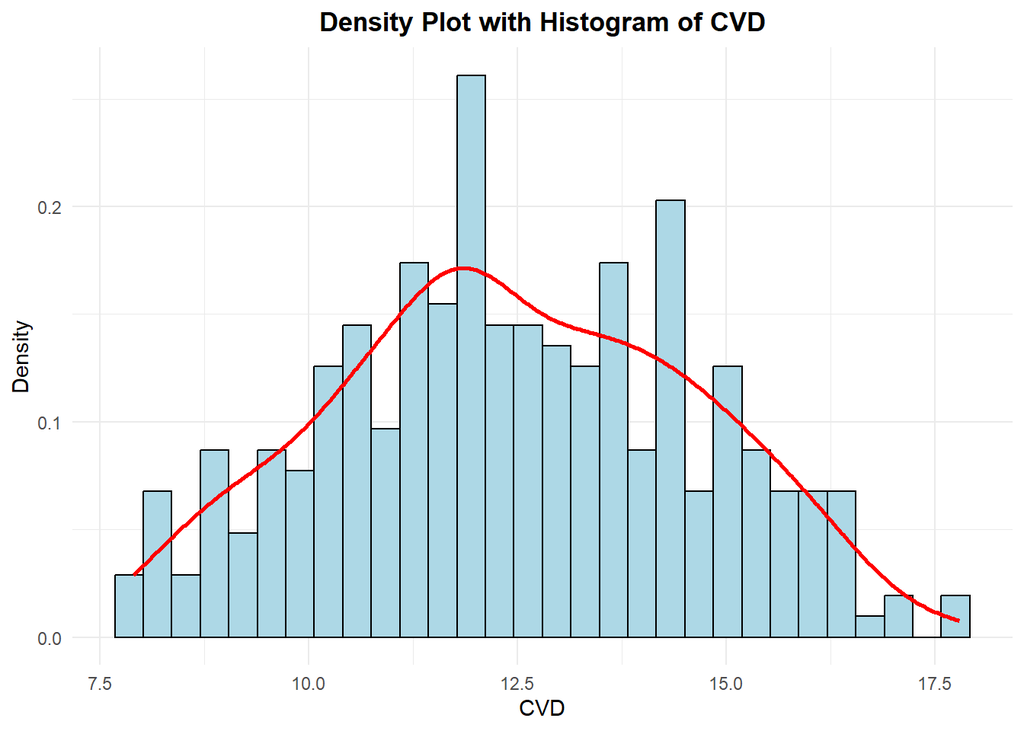

```r
#It shows a combined density plot and histogram to visualize the distribution of Cardiovascular Disease (CVD) values in the dataset

ggplot(cvd_data, aes(x = CVD)) +
  geom_histogram(aes(y = ..density..), bins = 30, fill = "lightblue", color = "black") +
  geom_density(color = "red", linewidth = 1) +
  labs(
    title = "Density Plot with Histogram of CVD",
    x = "CVD",
    y = "Density"
  ) +
  theme_minimal() +
  theme(plot.title = element_text(hjust = 0.5, face = "bold"))
```

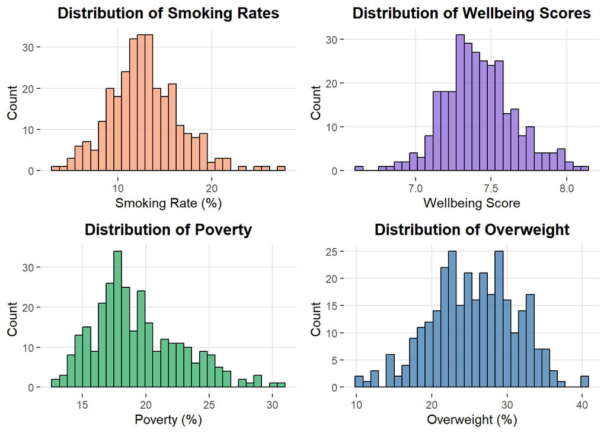

```r
common_theme <- theme(
  plot.title = element_text(hjust = 0.5, face = "bold"),
  panel.background = element_rect(fill = "white"),
  panel.grid.major = element_line(color = "grey90")
)

# Plot 2: Distribution of Smoking Rates
p2 <- ggplot(cvd_data, aes(x = smokers)) +
  geom_histogram(color = "black", fill = "#ffa07a", alpha = 0.8) +
  labs(
    title = "Distribution of Smoking Rates",
    x = "Smoking Rate (%)",
    y = "Count"
  ) +
  common_theme

# Plot 3: Distribution of Wellbeing Scores
p3 <- ggplot(cvd_data, aes(x = wellbeing)) +
  geom_histogram(color = "black", fill = "#9370db", alpha = 0.8) +
  labs(
    title = "Distribution of Wellbeing Scores",
    x = "Wellbeing Score",
    y = "Count"
  ) +
  common_theme

# Plot 4: Distribution of Poverty
p4 <- ggplot(cvd_data, aes(x = Poverty)) +
  geom_histogram(color = "black", fill = "#3cb371", alpha = 0.8) +
  labs(
    title = "Distribution of Poverty",
    x = "Poverty (%)",
    y = "Count"
  ) +
  common_theme

# Plot 5: Distribution of Overweight
p5 <- ggplot(cvd_data, aes(x = overweight)) +
  geom_histogram(color = "black", fill = "#4682b4", alpha = 0.8) +
  labs(
    title = "Distribution of Overweight",
    x = "Overweight (%)",
    y = "Count"
  ) +
  common_theme

# Arrange and display the plots
grid.arrange(p2, p3, p4, p5, ncol = 2, nrow = 2)
```

### 2. Distribution of Wellbeing Scores

Wellbeing scores exhibit a slight rightward skew, predominantly clustering between values of 7.0 and 8.0, culminating in an average score of approximately 7.5. A number of scores falling under the threshold of 7.0 indicate possible regional differences in wellbeing that may require further examination.

#### Scatter Plot of CVD with other factors

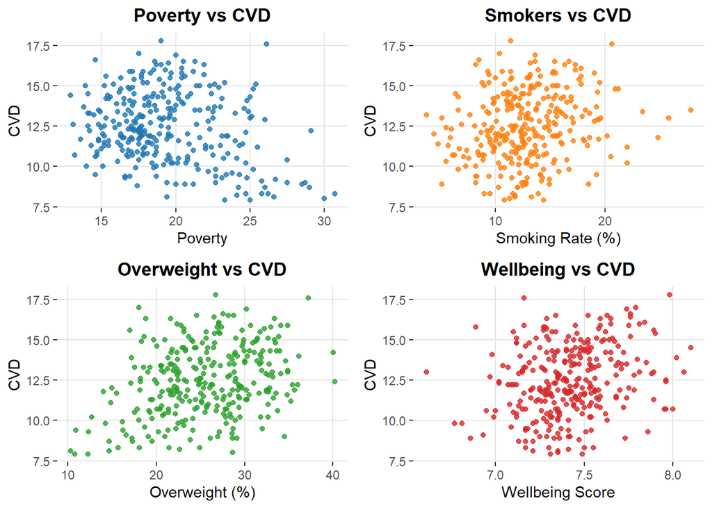

```r
common_theme <- theme(
  plot.title = element_text(hjust = 0.5, face = "bold"),
  panel.background = element_rect(fill = "white"),
  panel.grid.major = element_line(color = "grey90")
)

# Plot 1: Poverty vs CVD
plot1 <- ggplot(cvd_data, aes(x = Poverty, y = CVD)) +
  geom_point(color = "#1f77b4", alpha = 0.8) +
  labs(
    title = "Poverty vs CVD",
    x = "Poverty",
    y = "CVD"
  ) +
  common_theme

# Plot 2: Smokers vs CVD
plot2 <- ggplot(cvd_data, aes(x = smokers, y = CVD)) +
  geom_point(color = "#ff7f0e", alpha = 0.8) +
  labs(
    title = "Smokers vs CVD",
    x = "Smoking Rate (%)",
    y = "CVD"
  ) +
  common_theme

# Plot 3: Overweight vs CVD
plot3 <- ggplot(cvd_data, aes(x = overweight, y = CVD)) +
  geom_point(color = "#2ca02c", alpha = 0.8) +
  labs(
    title = "Overweight vs CVD",
    x = "Overweight (%)",
    y = "CVD"
  ) +
  common_theme

# Plot 4: Wellbeing vs CVD
plot4 <- ggplot(cvd_data, aes(x = wellbeing, y = CVD)) +
  geom_point(color = "#d62728", alpha = 0.8) +
  labs(
    title = "Wellbeing vs CVD",
    x = "Wellbeing Score",
    y = "CVD"
  ) +
  common_theme

# Arrange and display the plots in a grid
grid.arrange(plot1, plot2, plot3, plot4, ncol = 2, nrow = 2)
```

### Corelation Matrix

```r
# numeric columns
numeric_data <- cvd_data %>%
  select(CVD, Poverty, overweight, smokers, wellbeing)

# correlation matrix and p-values using Hmisc's rcorr function
correlation_results <- Hmisc::rcorr(as.matrix(numeric_data))

# correlation coefficients and p-values
correlation_results
```

```
##              CVD Poverty overweight smokers wellbeing
## CVD         1.00   -0.25       0.32    0.18      0.25
## Poverty    -0.25    1.00       0.14    0.36     -0.35
## overweight  0.32    0.14       1.00    0.40     -0.04
## smokers     0.18    0.36       0.40    1.00     -0.20
## wellbeing   0.25   -0.35      -0.04   -0.20      1.00
##
## n= 303
##
##
## P
##            CVD    Poverty overweight smokers wellbeing
## CVD               0.0000  0.0000     0.0019  0.0000
## Poverty    0.0000         0.0152     0.0000  0.0000
## overweight 0.0000 0.0152             0.0000  0.4681
## smokers    0.0019 0.0000  0.0000             0.0005
## wellbeing  0.0000 0.0000  0.4681     0.0005
```

#### Analyzing Correlation Matrix and the P Values

Next, we are summarizing the relationships between Cardiovascular Disease (CVD), Poverty, Overweight, Smokers and Wellbeing based on the correlation matrix and p-values above. Key observations include:

1. CVD and Poverty:
- A moderate negative correlation ($r = -0.25$) is established between higher poverty rates and lower CVD prevalence.
- There is a statistically significant relationship between the two variables ($p < 0.05$).
2. CVD and Overweight: – A moderate positive correlation ($r = 0.32$) indicates that higher proportion of people with overweight is correlated with higher prevalence of CVD.
- Relationship is very significant ($p < 0.001$)
3. CVD and Smokers: – A weak positive correlation ($r = 0.18$), indicating that increased smoking rates are linked with a slightly increased CVD prevalence.
- This association is statistically significant ($p = 0.0019$).
4. CVD and Wellbeing:
- A moderate positive correlation ($r = 0.25$) indicates that individuals with higher wellbeing scores tend to have a slightly higher prevalence of CVD. This result is statistically significant ($p < 0.001$).
5. Poverty and Wellbeing:
- A negative correlation of -0.35 means that higher levels of poverty are correlated with lower levels of wellbeing.
- That relationship is statistically significant ($p < 0.001$).
6. Additional Significant Relationships:
- Overweight and Smokers, moderate positive correlation ($r = 0.40$): Higher overweight percentage relates to higher percentage of smokers.
- Smokers & Wellbeing have a weak negative correlation ($r = -0.20$) indicating that as rates of smoking go up, wellbeing slightly declines.

## Linear Regression

```r
# linear regression model
cvd_model <- lm(
  formula = CVD ~ overweight + smokers + wellbeing + Poverty,
  data = cvd_data,
  weights = Population
)

# summary of the model
summary(cvd_model)
```

```
##
## Call:
## lm(formula = CVD ~ overweight + smokers + wellbeing + Poverty,
##     data = cvd_data, weights = Population)
##
## Weighted Residuals:
##      Min       1Q   Median       3Q      Max
## -1917.48  -523.86   -17.22   494.96  2305.04
##
## Coefficients:
##             Estimate Std. Error t value Pr(>|t|)
## (Intercept)  1.29477    4.28984   0.302 0.762998
## overweight   0.11787    0.02137   5.515 7.55e-08 ***
## smokers      0.12501    0.03656   3.419 0.000717 ***
## wellbeing    1.45165    0.53916   2.692 0.007495 **
## Poverty     -0.22287    0.03230  -6.900 3.13e-11 ***
## ---
## Signif. codes:  0 '***' 0.001 '**' 0.01 '*' 0.05 '.' 0.1 ' ' 1
##
## Residual standard error: 757.4 on 298 degrees of freedom
## Multiple R-squared:  0.314,  Adjusted R-squared:  0.3048
## F-statistic: 34.11 on 4 and 298 DF,  p-value: < 2.2e-16
```

```r
# confidence intervals for the model coefficients
confidence_intervals <- confint(cvd_model)

# confidence intervals
print(confidence_intervals)
```

```
##                   2.5 %     97.5 %
## (Intercept) -7.14745422  9.7369958
## overweight   0.07581463  0.1599300
## smokers      0.05305008  0.1969633
## wellbeing    0.39060787  2.5126843
## Poverty     -0.28644083 -0.1593075
```

### Examining the Linear Regression Model

We will find out how does Cardiovascular Disease (CVD) prevalence (dependent variable) dependent on those common factors weighted by the population by applying a linear regression thus we will evaluate relationship between dependent on overweight, smokers, wellbeing, poverty.

#### Key Findings:

Using estimation Method: The results indicate:

- A significant positive effect of overweight on CVD ($t(298) = 5.515$), ($p < .001$), with every 1 unit increase in overweight predicting an average increase of 0.12 units in CVD (95% CI = [0.076, 0.160]).
- A significant positive effect of smokers on CVD ($t(298) = 3.419$), ($p < .001$), with every 1 unit increase in the number of smokers predicting an average increase of 0.13 units in CVD (95% CI = [0.053, 0.197]).
- A significant positive effect of wellbeing on CVD ($t(298) = 2.692$), ($p = .007$), with every 1 unit increase in wellbeing predicting an average increase of 1.45 units in CVD (95% CI = [0.391, 2.513]).
- A significant negative effect of poverty on CVD ($t(298) = -6.900$), ($p < .001$), with every 1 unit increase in poverty predicting an average decrease of 0.22 units in CVD (95% CI = [-0.286, -0.159]).

```r
# Variance Inflation Factor (VIF) to check for multicollinearity
vif(cvd_model)
```

```
## overweight    smokers  wellbeing    Poverty
##   1.274217   1.445611   1.227777   1.322573
```

#### VIF

The VIF values suggested no multicollinearity if the VIF is less than 5 for the predictors in the regression model. The VIF for all predictors (overweight (VIF = 1.27), smokers (VIF = 1.45), wellbeing (VIF = 1.23), and poverty (VIF = 1.32)) are far below a common threshold of 5 indicating low multicollinearity. This implies a weak association of independent variables with each other and guarantees that each factor leads independent information to clarify the variation of CVD prevalence. The low VIF values increase the overall confidence in the model, given that the regression coefficients are stable, and that one can be confident in using the predictors for inference and prediction.

### Interaction Model

To better understand the factors influencing CVD prevalence, an interaction model was employed to evaluate the combined effects of overweight, smoking, wellbeing, and poverty on CVD rates.

```r
# Linear regression model with interaction terms
cvd_model_interaction <- lm(
  formula = CVD ~ (overweight + smokers + wellbeing + Poverty)^2,
  data = cvd_data,
  weights = Population
)

# interaction model
summary(cvd_model_interaction)
```

```
##
## Call:
## lm(formula = CVD ~ (overweight + smokers + wellbeing + Poverty)^2,
##     data = cvd_data, weights = Population)
##
## Weighted Residuals:
##      Min       1Q   Median       3Q      Max
## -1904.15  -493.43   -46.08   537.75  2039.69
##
## Coefficients:
##                        Estimate Std. Error t value Pr(>|t|)
## (Intercept)          -41.422821  29.458635  -1.406   0.1607
## overweight             0.537429   0.941149   0.571   0.5684
## smokers               -1.153714   1.286544  -0.897   0.3706
## wellbeing              7.883535   3.820770   2.063   0.0400 *
## Poverty                2.075312   1.131119   1.835   0.0676 .
## overweight:smokers    -0.005590   0.005708  -0.979   0.3283
## overweight:wellbeing  -0.085461   0.117482  -0.727   0.4675
## overweight:Poverty     0.014431   0.007159   2.016   0.0448 *
## smokers:wellbeing      0.195840   0.160009   1.224   0.2220
## smokers:Poverty       -0.002371   0.011040  -0.215   0.8301
## wellbeing:Poverty     -0.355229   0.152809  -2.325   0.0208 *
## ---
## Signif. codes:  0 '***' 0.001 '**' 0.01 '*' 0.05 '.' 0.1 ' ' 1
##
## Residual standard error: 750.4 on 292 degrees of freedom
## Multiple R-squared:  0.3402, Adjusted R-squared:  0.3176
## F-statistic: 15.05 on 10 and 292 DF,  p-value: < 2.2e-16
```

```r
# confidence intervals for the coefficients
interaction_confidence_intervals <- confint(cvd_model_interaction)
print(interaction_confidence_intervals)
```

```
##                              2.5 %       97.5 %
## (Intercept)          -9.940099e+01 16.555350334
## overweight           -1.314867e+00  2.389724606
## smokers              -3.685788e+00  1.378360033
## wellbeing             3.637952e-01 15.403274906
## Poverty              -1.508676e-01  4.301492543
## overweight:smokers   -1.682451e-02  0.005644897
## overweight:wellbeing -3.166804e-01  0.145758920
## overweight:Poverty    3.401235e-04  0.028521188
## smokers:wellbeing    -1.190766e-01  0.510756068
## smokers:Poverty      -2.409938e-02  0.019357702
## wellbeing:Poverty    -6.559751e-01 -0.054482016
```

The results indicate:

### Interaction Terms: Using Estimation

This analysis highlights that wellbeing and interactions between overweight and poverty (positive) and wellbeing and poverty (negative) significantly influence CVD, while other predictors and interactions are not statistically significant..

##Testing model significnace with ANOVA

```r
# ANOVA to compare the models
anova_comparison <- stats::anova(cvd_model, cvd_model_interaction)

# results of the comparison
anova_comparison
```

```
## Analysis of Variance Table
##
## Model 1: CVD ~ overweight + smokers + wellbeing + Poverty
## Model 2: CVD ~ (overweight + smokers + wellbeing + Poverty)^2
##   Res.Df       RSS Df Sum of Sq      F  Pr(>F)
## 1    298 170947772
## 2    292 164437745  6   6510027 1.9267 0.07638 .
## ---
## Signif. codes:  0 '***' 0.001 '**' 0.01 '*' 0.05 '.' 0.1 ' ' 1
```

### ANOVA Results

After rounding, the ANOVA comparison tests the significance of the difference between Model 1 (without interaction terms) and Model 2 (including interaction terms) to see if adding interactions produces a significantly better fitting model. The model with interaction terms (Model 2) explains only a small but non-significant ($p = 0.076)$) relative to the simpler model (Model 1).

## Visualizing Linear Models

### Figure that visualizes the effect of Poverty upon CVD and other variables

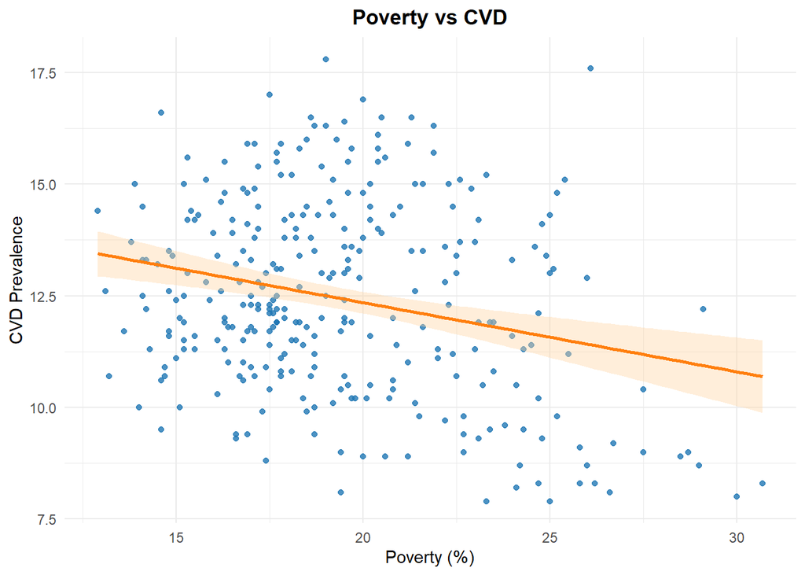

```r
# Plotting Poverty vs CVD with regression line
poverty_vs_cvd_plot <- ggplot(data = cvd_data, aes(x = Poverty, y = CVD)) +
  geom_point(color = "#1f77b4", alpha = 0.8) +  # Blue points
  geom_smooth(method = "lm", color = "#ff7f0e", fill = "#ffd4a3", se = TRUE) +
  labs(
    title = "Poverty vs CVD",
    x = "Poverty (%)",
    y = "CVD Prevalence"
  ) +
  theme_minimal() +  # Cleaner theme
  theme(
    plot.title = element_text(hjust = 0.5, face = "bold")
  )

print(poverty_vs_cvd_plot)
```

```r
common_theme <- theme(
  plot.title = element_text(hjust = 0.5, face = "bold"),
  panel.background = element_rect(fill = "white"),
  panel.grid.major = element_line(color = "grey90")
)
```

Poverty vs CVD

This suggests an inverse relationship of poverty rates with CVD prevalence as depicted by the negative sloping regression line in the graph. This indicates that with increasing poverty, CVD prevalence tends to decrease slightly. On the downside, we note that the data points are spread quite widely, suggesting a weak correlation. The confidence interval around the regression line is narrow and shaded, indicating stable estimates. Two outliers that fall farthest at either end of the poverty rate spectrum do not necessarily fit the trend, possibly suggesting regional variances. Such a relationship could be due to multifactorial socio-economic drivers, meriting further analysis to identify root causes.

## Conclusion

The findings indicate that multiple factors notably affect the occurrence of cardiovascular disease (CVD) within a region. Specifically, areas characterized by a higher percentage of overweight individuals generally experience a modest rise in CVD rates; for every 1% increase in the population deemed overweight, there is an anticipated 0.12% escalation in CVD cases. Likewise, regions with elevated smoking rates observe a similar trend: each additional 1% of smokers correlates with a 0.13% uptick in CVD prevalence. Conversely, it is noteworthy that increased wellbeing scores correlate positively with CVD incidence—each unit increment in wellbeing predictions corresponds to an approximate rise of 1.45% in CVD rates. In contrast, poverty appears to exert a protective influence; specifically, when poverty levels increase by 1%, there tends to be an associated decrease of about 0.22% in instances of CVD. These results underscore the complex relationships between these various factors and their differing implications on cardiovascular health outcomes.

# Question 2

## Introduction

This part explores what drives customer satisfaction, examining correlations between customer satisfaction and staff satisfaction scores, average delivery time for large and bespoke items, new product range availability, and the store SES classification. It also indicates whether delivery times are correlated with the level of customer satisfaction in both high, medium and low SIS stores consistently. This analysis is conducted using professional statistical practices, and reproducible code is provided to facilitate transparency and confirmability.

## Data Dictionary

| Variable | Description |
| --- | --- |
| SES category | The socio-economic status of the customer |
| Customer satisfaction | shows the level of customer satisfaction |
| Staff satisfaction | shows the level of satisfaction of staff |
| Delivery time | The total time taken for the product to be delivered |
| New range | shows true/false column based on condition |

## Exploratory Analysis

### Data Understanding

```r
# Loading the dataset
cust_data <- read_csv("cust_satisfaction.csv")
summary(cust_data)
```

```
##  SES_category       customer.satisfaction staff.satisfaction delivery.time
##  Length:300         Min.   :3.760         Min.   :4.850      Min.   :32.96
##  Class :character   1st Qu.:6.099         1st Qu.:6.216      1st Qu.:52.46
##  Mode  :character   Median :7.006         Median :6.634      Median :60.45
##                     Mean   :6.930         Mean   :6.751      Mean   :59.60
##                     3rd Qu.:7.865         3rd Qu.:7.274      3rd Qu.:66.79
##                     Max.   :9.670         Max.   :8.860      Max.   :92.48
##  new_range
##  Mode :logical
##  FALSE:142
##  TRUE :158
##
##
##
```

### Data Preparation

```r
# The conversion of categorical data to factors
cust_data$SES_category <- factor(cust_data$SES_category, levels = c("Low", "Medium", "High"))
cust_data$new_range <- as.factor(cust_data$new_range)
```

### Data Visualization

#### Illustrating the Distribution of Customer Satisfaction Scores

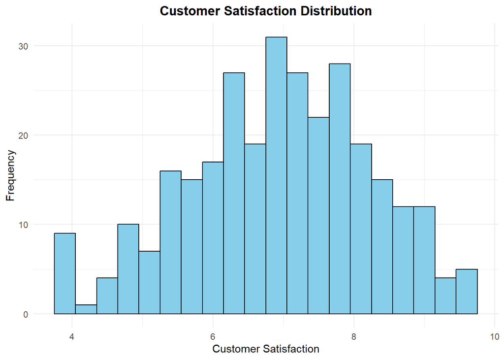

```r
ggplot(cust_data, aes(x = customer.satisfaction)) +
  geom_histogram(binwidth = 0.3, fill = "skyblue", color = "black") +
  labs(
    title = "Customer Satisfaction Distribution",
    x = "Customer Satisfaction",
    y = "Frequency"
  ) +
  theme_minimal() +
  theme(plot.title = element_text(hjust = 0.5, face = "bold"))
```

The histogram illustrates the spread of customer satisfaction ratings. These scores fall between about 4 and 10, with a significant number of customers indicating satisfaction levels from 6 to 8. The distribution appears largely symmetrical, reflecting an even dispersion in satisfaction ratings, peaking around a score of 7. This implies that most customers feel moderately too highly satisfied. Instances of low or high outlier scores are infrequent, suggesting overall consistency in customer satisfaction within the dataset.

#### Illustrating the Distribution of Delivery Time and Employee Satisfaction

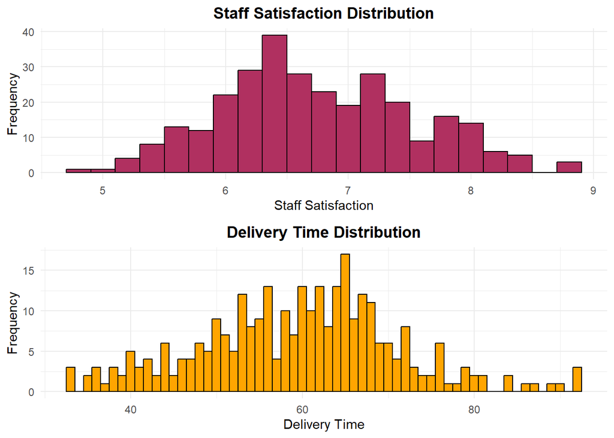

```r
# Ploting for Staff Satisfaction Distribution
g2 <- ggplot(cust_data, aes(x = staff.satisfaction)) +
  geom_histogram(binwidth = 0.2, fill = "maroon", color = "black") +
  labs(
    title = "Staff Satisfaction Distribution",
    x = "Staff Satisfaction",
    y = "Frequency"
  ) +
  theme_minimal() +
  theme(plot.title = element_text(hjust = 0.5, face = "bold"))

# Ploting for Delivery Time Distribution
g3 <- ggplot(cust_data, aes(x = delivery.time)) +
  geom_histogram(binwidth = 1, fill = "orange", color = "black") +
  labs(
    title = "Delivery Time Distribution",
    x = "Delivery Time",
    y = "Frequency"
  ) +
  theme_minimal() +
  theme(plot.title = element_text(hjust = 0.5, face = "bold"))


grid.arrange(g2, g3)
```

In contrast, the Delivery Time Distribution graph reveals that delivery times extend from about 30 to 90, peaking at around 60. This distribution shows a slight right skewness, indicating there are few cases where delivery times are significantly longer than average.

Overall, these distributions underscore a general stability in both staff satisfaction and delivery times while showing few extreme outliers in either measure.

## Linear Regression

```r
# Step 5: Linear Modeling
lm_model <- lm(customer.satisfaction ~ SES_category + staff.satisfaction + delivery.time + new_range,
               data = cust_data)

# Model summary and confidence intervals
list(
  Summary = summary(lm_model),
  ConfidenceIntervals = confint(lm_model)
)
```

```
## $Summary
##
## Call:
## lm(formula = customer.satisfaction ~ SES_category + staff.satisfaction +
##     delivery.time + new_range, data = cust_data)
##
## Residuals:
##      Min       1Q   Median       3Q      Max
## -2.59866 -0.67952 -0.01176  0.65469  2.89231
##
## Coefficients:
##                     Estimate Std. Error t value Pr(>|t|)
## (Intercept)         4.962568   0.605210   8.200 7.55e-15 ***
## SES_categoryMedium  1.465058   0.155593   9.416  < 2e-16 ***
## SES_categoryHigh    0.255765   0.138541   1.846 0.065878 .
## staff.satisfaction  0.351113   0.080457   4.364 1.77e-05 ***
## delivery.time      -0.017220   0.004948  -3.480 0.000577 ***
## new_rangeTRUE       0.093878   0.112249   0.836 0.403643
## ---
## Signif. codes:  0 '***' 0.001 '**' 0.01 '*' 0.05 '.' 0.1 ' ' 1
##
## Residual standard error: 0.9687 on 294 degrees of freedom
## Multiple R-squared:  0.447,  Adjusted R-squared:  0.4376
## F-statistic: 47.53 on 5 and 294 DF,  p-value: < 2.2e-16
##
##
## $ConfidenceIntervals
##                          2.5 %       97.5 %
## (Intercept)         3.77147459  6.153661005
## SES_categoryMedium  1.15884194  1.771274609
## SES_categoryHigh   -0.01689271  0.528422930
## staff.satisfaction  0.19276839  0.509457959
## delivery.time      -0.02695804 -0.007481643
## new_rangeTRUE      -0.12703512  0.314791616
```

### Linear Regression Model Overview

The model accounts for 43.76% of the variability in customer satisfaction ($R^2 = 0.4376$), ($p < 0.0001$).

1. key Predictors:
   - SES (Medium): Exhibits a positive influence ($\beta = 1.465$), ($p < 0.001$).
   - Staff Satisfaction: Shows a positive correlation ($\beta = 0.351$), ($p < 0.001$).
   - Delivery Time: Demonstrates a negative effect ($\beta = -0.017$), ($p < 0.001$).
2. Predictors with No Significant Impact:
   - SES (High): Displays minimal impact ($p = 0.065$).
   - new_range: Indicates no significant influence ($p = 0.404$).

The primary factors influencing customer satisfaction include SES at the medium level, staff happiness, and delivery time considerations.

```r
#LM model with interaction of SES on delivery
model_delivery_interaction <- lm(customer.satisfaction ~ delivery.time * SES_category, data = cust_data)
summary(model_delivery_interaction)
```

```
##
## Call:
## lm(formula = customer.satisfaction ~ delivery.time * SES_category,
##     data = cust_data)
##
## Residuals:
##      Min       1Q   Median       3Q      Max
## -2.43290 -0.63000  0.00057  0.72673  2.52903
##
## Coefficients:
##                                   Estimate Std. Error t value Pr(>|t|)
## (Intercept)                       6.498601   0.522291  12.443  < 2e-16 ***
## delivery.time                    -0.004944   0.008224  -0.601 0.548142
## SES_categoryMedium                2.418677   0.727364   3.325 0.000995 ***
## SES_categoryHigh                  2.122323   0.774569   2.740 0.006519 **
## delivery.time:SES_categoryMedium -0.010389   0.011991  -0.866 0.386954
## delivery.time:SES_categoryHigh   -0.029762   0.012535  -2.374 0.018221 *
## ---
## Signif. codes:  0 '***' 0.001 '**' 0.01 '*' 0.05 '.' 0.1 ' ' 1
##
## Residual standard error: 0.9916 on 294 degrees of freedom
## Multiple R-squared:  0.4205, Adjusted R-squared:  0.4107
## F-statistic: 42.67 on 5 and 294 DF,  p-value: < 2.2e-16
```

```r
confint(model_delivery_interaction)
```

```
##                                        2.5 %       97.5 %
## (Intercept)                       5.47069931  7.526503687
## delivery.time                    -0.02112920  0.011240329
## SES_categoryMedium                0.98717631  3.850177673
## SES_categoryHigh                  0.59792116  3.646725172
## delivery.time:SES_categoryMedium -0.03398802  0.013209335
## delivery.time:SES_categoryHigh   -0.05443078 -0.005092879
```

### Interpretation of Confidence Intervals

```r
# Step 5: Linear Modeling with Interaction Term
lm_model_2 <- lm(customer.satisfaction ~ SES_category + staff.satisfaction + SES_category:delivery.time + new_range,
                 data = cust_data)

# model summary and confidence intervals
model_summary <- summary(lm_model_2)
model_confint <- confint(lm_model_2)

# results
list(Summary = model_summary, ConfidenceIntervals = model_confint)
```

```
## $Summary
##
## Call:
## lm(formula = customer.satisfaction ~ SES_category + staff.satisfaction +
##     SES_category:delivery.time + new_range, data = cust_data)
##
## Residuals:
##      Min       1Q   Median       3Q      Max
## -2.69336 -0.63905 -0.02235  0.64181  2.70571
##
## Coefficients:
##                                   Estimate Std. Error t value Pr(>|t|)
## (Intercept)                       4.068239   0.730090   5.572 5.72e-08 ***
## SES_categoryMedium                2.224086   0.705663   3.152  0.00179 **
## SES_categoryHigh                  2.225232   0.750829   2.964  0.00329 **
## staff.satisfaction                0.359605   0.079847   4.504 9.67e-06 ***
## new_rangeTRUE                     0.104057   0.111400   0.934  0.35103
## SES_categoryLow:delivery.time    -0.003839   0.007972  -0.482  0.63049
## SES_categoryMedium:delivery.time -0.016019   0.008468  -1.892  0.05953 .
## SES_categoryHigh:delivery.time   -0.036301   0.009168  -3.960 9.44e-05 ***
## ---
## Signif. codes:  0 '***' 0.001 '**' 0.01 '*' 0.05 '.' 0.1 ' ' 1
##
## Residual standard error: 0.9603 on 292 degrees of freedom
## Multiple R-squared:  0.4602, Adjusted R-squared:  0.4473
## F-statistic: 35.57 on 7 and 292 DF,  p-value: < 2.2e-16
##
##
## $ConfidenceIntervals
##                                        2.5 %        97.5 %
## (Intercept)                       2.63133395  5.5051447083
## SES_categoryMedium                0.83525551  3.6129169371
## SES_categoryHigh                  0.74750992  3.7029542039
## staff.satisfaction                0.20245732  0.5167533288
## new_rangeTRUE                    -0.11519251  0.3233064416
## SES_categoryLow:delivery.time    -0.01952751  0.0118503328
## SES_categoryMedium:delivery.time -0.03268607  0.0006475547
## SES_categoryHigh:delivery.time   -0.05434432 -0.0182578844
```

### Linear Regression Model with Interaction Term: Results

This model assesses the factors influencing customer satisfaction, incorporating an interaction term between SES_category and delivery time. The primary findings are summarized below:

1. Model Fit:
   - Adjusted ($R^2 = 0.4473$): This indicates that 44.73% of the variability in customer satisfaction can be explained by the model.
   - F-statistic ($p < 0.0001$): The overall significance of the model is confirmed.
2. Main Effects:
   - SES_category (Medium and High): Both categories show a significant positive relationship with customer satisfaction ($\beta = 2.224$, $p = 0.0018$),($\beta = 2.225$, $p = 0.0033$).
   - Staff Satisfaction: There is a notable positive influence on customer satisfaction ($\beta = 0.360$, $p < 0.0001$).
   - Delivery Time: For the reference level of SES, no significant effect was found ($p = 0 .63$).
3. Interaction Effects:
   - SES_category (High) x Delivery Time: A statistically significant negative interaction exists ($\beta = -0 .036$, $p < 0 .0001$), suggesting that longer delivery times adversely affect High SES customers more intensely.
   - SES_category (Medium) x Delivery Time: A nearly significant negative interaction was noted ($\beta=-0 .016$ ,$p=059$).
4. Non-Significant Predictors: new_range: No noteworthy impact observed ($p=035$)

5.Confidence Intervals: Significant predictors such as SES category and staff satisfaction have confidence intervals excluding zero for their respective effects.

Customer satisfaction is notably affected by SES_category levels, staff contentment, and their interplay with delivery time—especially among those in higher socioeconomic status groups where extended delivery periods exert greater detrimental effects compared to other segments.

```r
confint(lm_model_2)
```

```
##                                        2.5 %        97.5 %
## (Intercept)                       2.63133395  5.5051447083
## SES_categoryMedium                0.83525551  3.6129169371
## SES_categoryHigh                  0.74750992  3.7029542039
## staff.satisfaction                0.20245732  0.5167533288
## new_rangeTRUE                    -0.11519251  0.3233064416
## SES_categoryLow:delivery.time    -0.01952751  0.0118503328
## SES_categoryMedium:delivery.time -0.03268607  0.0006475547
## SES_categoryHigh:delivery.time   -0.05434432 -0.0182578844
```

### Interpretation of Confidence Intervals

Significant Predictors:

1. SES_category (Medium, High): Indicate positive effects as the confidence intervals do not encompass zero.
2. Staff Satisfaction: Shows a positive relationship with a confidence interval ranging from [0.203 to 0.517].
3. SES_category (High) x Delivery Time: Represents a negative interaction effect, indicated by the confidence interval of [-0.054 to -0.019].

Non-Significant Predictors:

1. The variable new_range, along with interactions involving SES_category (Low, Medium) x Delivery Time, presents confidence intervals that include zero.

Customer satisfaction is significantly influenced by SES categories classified as Medium and High, staff satisfaction levels, and the interaction between high SES and delivery time

### ANOVA

```r
anova(lm_model,lm_model_2)
```

```
## Analysis of Variance Table
##
## Model 1: customer.satisfaction ~ SES_category + staff.satisfaction + delivery.time +
##     new_range
## Model 2: customer.satisfaction ~ SES_category + staff.satisfaction + SES_category:delivery.time +
##     new_range
##   Res.Df    RSS Df Sum of Sq      F  Pr(>F)
## 1    294 275.86
## 2    292 269.26  2    6.6032 3.5805 0.02909 *
## ---
## Signif. codes:  0 '***' 0.001 '**' 0.01 '*' 0.05 '.' 0.1 ' ' 1
```

The ANOVA analysis assesses two models to determine the impact of including the interaction term `SES_category:delivery.time`. Model 1 consists of the main effects from `SES_category`, `staff.satisfaction`, `delivery.time`, and `new_range`. In contrast, Model 2 adds this interaction term. The findings reveal that incorporating the interaction term significantly enhances model performance, as evidenced by an F-statistic of (3.5805) with a (p)-value of 0.029. The additional variance accounted for by this interaction is measured at 6.6032 units. This indicates that delivery time’s influence on customer satisfaction differs based on SES category, highlighting the relevance of adding this interaction term to appropriately capture these variations.

```r
emm <- emmeans(lm_model_2, ~ SES_category | delivery.time)
summary(emm)
```

```
## delivery.time = 59.6:
##  SES_category emmean     SE  df lower.CL upper.CL
##  Low            6.32 0.1020 292     6.12     6.52
##  Medium         7.82 0.1070 292     7.61     8.03
##  High           6.61 0.0969 292     6.42     6.80
##
## Results are averaged over the levels of: new_range
## Confidence level used: 0.95
```

## Conclusion

In conclusion, Medium SES consistently demonstrates superior overall satisfaction compared to other groups as longer wait times correlate negatively with their happiness levels—in particular for those within the High SES bracket—as evidenced by data reflecting that quicker deliveries yield optimal customer gratification.